# Chapter 2 - Analysis: Unburned Canopy (with NB)

Anna Talucci

February 13, 2019

# Packages

The following Packages are required for the below analyses:

```r
library(dplyr)
library(tidyr)
library(ggplot2)
library(MASS)
library(GGally)
library(cowplot)
library(car)
library(DHARMa)
library(lsmeans)
library(grid)
library(gridExtra)
library(gtable)
library()
```

# UNBURNED PLOTS/DATA

## UNBURNDED: saplings from Beetle

### Data

```r
un.sap = read.csv("../data/chapter2_saplings_unburned_30october2017.csv", header=TRUE, sep = ",", strip.white = TRUE)
head(un.sap)
```

|  | plot | date | plot.id | sapling.id | all.whorls | leader | false.whorls | est.age | age | DBH | disturbance |
| --- | --- | --- | --- | --- | --- | --- | --- | --- | --- | --- | --- |
| 1 | 64 | 6/30/2016 | CEC0630U1 | se1 | 16 | 1 | na | 17 | 17 | 5.5 | beetle.only |
| 2 | 64 | 6/30/2016 | CEC0630U1 | se2 | 34 | 1 | na | 35 | 35 | 7.5 | beetle.only |
| 3 | 64 | 6/30/2016 | CEC0630U1 | ne1 | 29 | 1 | na | 30 | 30 | 7.5 | beetle.only |
| 4 | 64 | 6/30/2016 | CEC0630U1 | ne2 | 28 | 1 | na | 29 | 29 | 4.5 | beetle.only |
| 5 | 64 | 6/30/2016 | CEC0630U1 | ne3 | 16 | 1 | na | 17 | 17 | 3.0 | beetle.only |
| 6 | 64 | 6/30/2016 | CEC0630U1 | ne4 | 12 | 1 | na | 13 | 13 | 1.0 | beetle.only |

```r
summary(un.sap)
```

```
      plot              date          plot.id      sapling.id
 Min.   :64.00   7/29/2016:111   BA0729U2 : 69   sw1    : 19
 1st Qu.:70.00   8/1/2016 : 74   BA0801U1 : 61   nw1    : 18
 Median :75.00   7/8/2016 : 73   TL0809U1 : 48   nw2    : 18
 Mean   :74.53   8/12/2016: 59   BA0729U1 : 42   se1    : 18
 3rd Qu.:79.00   8/9/2016 : 48   CEC0703U1: 40   ne1    : 17
 Max.   :83.00   7/3/2016 : 40   CEC0780U2: 37   se2    : 17
                 (Other)  :147   (Other)  :255   (Other):445
   all.whorls        leader        false.whorls    est.age
 Min.   : 0.00   Min.   :0.0000   0      :318   Min.   : 1.00
 1st Qu.: 5.00   1st Qu.:1.0000   na     :154   1st Qu.: 6.00
 Median :10.00   Median :1.0000   1      : 48   Median :11.00
 Mean   :11.89   Mean   :0.9964   2      : 18   Mean   :12.89
 3rd Qu.:16.00   3rd Qu.:1.0000   3      :  7   3rd Qu.:17.00
 Max.   :48.00   Max.   :1.0000   4      :  5   Max.   :49.00
                                  (Other):  2
      age             DBH              disturbance
 Min.   : 1.00   Min.   : 0.500   beetle.only:552
 1st Qu.: 6.00   1st Qu.: 0.500
 Median :11.00   Median : 1.000
 Mean   :12.89   Mean   : 1.699
 3rd Qu.:17.00   3rd Qu.: 2.000
 Max.   :49.00   Max.   :10.000
```

```r
un.sap
```

| plot | date | plot.id | sapling.id | all.whorls | leader | false.whorls | est.age | age | DBH | disturbance |
| --- | --- | --- | --- | --- | --- | --- | --- | --- | --- | --- |
| 64 | 6/30/2016 | CEC0630U1 | se1 | 16 | 1 | na | 17 | 17 | 5.5 | beetle.only |
| 64 | 6/30/2016 | CEC0630U1 | se2 | 34 | 1 | na | 35 | 35 | 7.5 | beetle.only |
| 64 | 6/30/2016 | CEC0630U1 | ne1 | 29 | 1 | na | 30 | 30 | 7.5 | beetle.only |
| 64 | 6/30/2016 | CEC0630U1 | ne2 | 28 | 1 | na | 29 | 29 | 4.5 | beetle.only |
| 64 | 6/30/2016 | CEC0630U1 | ne3 | 16 | 1 | na | 17 | 17 | 3.0 | beetle.only |
| 64 | 6/30/2016 | CEC0630U1 | ne4 | 12 | 1 | na | 13 | 13 | 1.0 | beetle.only |
| 64 | 6/30/2016 | CEC0630U1 | nw1 | 16 | 1 | na | 17 | 17 | 2.0 | beetle.only |
| 64 | 6/30/2016 | CEC0630U1 | nw2 | 26 | 1 | na | 27 | 27 | 6.0 | beetle.only |
| 64 | 6/30/2016 | CEC0630U1 | nw3 | 36 | 1 | na | 37 | 37 | 9.0 | beetle.only |
| 64 | 6/30/2016 | CEC0630U1 | sw1 | 34 | 1 | na | 35 | 35 | 8.5 | beetle.only |

[output cut: 542 more lines]

```r
un.sap$agesplit = ifelse(un.sap$age <= 27, 1, 2)
head(un.sap)
```

|  | plot | date | plot.id | sapling.id | all.whorls | leader | false.whorls | est.age | age | DBH | disturbance | agesplit |
| --- | --- | --- | --- | --- | --- | --- | --- | --- | --- | --- | --- | --- |
| 1 | 64 | 6/30/2016 | CEC0630U1 | se1 | 16 | 1 | na | 17 | 17 | 5.5 | beetle.only | 1 |
| 2 | 64 | 6/30/2016 | CEC0630U1 | se2 | 34 | 1 | na | 35 | 35 | 7.5 | beetle.only | 2 |
| 3 | 64 | 6/30/2016 | CEC0630U1 | ne1 | 29 | 1 | na | 30 | 30 | 7.5 | beetle.only | 2 |
| 4 | 64 | 6/30/2016 | CEC0630U1 | ne2 | 28 | 1 | na | 29 | 29 | 4.5 | beetle.only | 2 |
| 5 | 64 | 6/30/2016 | CEC0630U1 | ne3 | 16 | 1 | na | 17 | 17 | 3.0 | beetle.only | 1 |
| 6 | 64 | 6/30/2016 | CEC0630U1 | ne4 | 12 | 1 | na | 13 | 13 | 1.0 | beetle.only | 1 |

```r
ageperiod = subset(un.sap, agesplit == "1")
head(ageperiod)
```

|  | plot | date | plot.id | sapling.id | all.whorls | leader | false.whorls | est.age | age | DBH | disturbance | agesplit |
| --- | --- | --- | --- | --- | --- | --- | --- | --- | --- | --- | --- | --- |
| 1 | 64 | 6/30/2016 | CEC0630U1 | se1 | 16 | 1 | na | 17 | 17 | 5.5 | beetle.only | 1 |
| 5 | 64 | 6/30/2016 | CEC0630U1 | ne3 | 16 | 1 | na | 17 | 17 | 3.0 | beetle.only | 1 |
| 6 | 64 | 6/30/2016 | CEC0630U1 | ne4 | 12 | 1 | na | 13 | 13 | 1.0 | beetle.only | 1 |
| 7 | 64 | 6/30/2016 | CEC0630U1 | nw1 | 16 | 1 | na | 17 | 17 | 2.0 | beetle.only | 1 |
| 8 | 64 | 6/30/2016 | CEC0630U1 | nw2 | 26 | 1 | na | 27 | 27 | 6.0 | beetle.only | 1 |
| 11 | 65 | 6/30/2016 | CEC0630U2 | sw1 | 17 | 1 | na | 18 | 18 | 2.0 | beetle.only | 1 |

```r
summary(ageperiod)
```

```
      plot              date          plot.id      sapling.id    all.whorls
 Min.   :64.00   7/29/2016:111   BA0729U2 : 69   se1    : 17   Min.   : 0.000
 1st Qu.:72.00   8/1/2016 : 74   BA0801U1 : 61   nw1    : 16   1st Qu.: 5.000
 Median :75.00   7/8/2016 : 51   BA0729U1 : 42   sw1    : 16   Median : 9.000
 Mean   :74.69   8/12/2016: 51   CEC0703U1: 39   sw2    : 16   Mean   : 9.819
 3rd Qu.:78.75   7/3/2016 : 39   TL0809U1 : 37   ne2    : 15   3rd Qu.:14.000
 Max.   :83.00   8/8/2016 : 38   BA0731U1 : 34   nw2    : 15   Max.   :26.000
                 (Other)  :138   (Other)  :220   (Other):407
     leader       false.whorls    est.age           age             DBH
 Min.   :0.000   0      :309   Min.   : 1.00   Min.   : 1.00   Min.   :0.500
 1st Qu.:1.000   na     :123   1st Qu.: 6.00   1st Qu.: 6.00   1st Qu.:0.500
 Median :1.000   1      : 42   Median :10.00   Median :10.00   Median :1.000
 Mean   :0.996   2      : 16   Mean   :10.81   Mean   :10.81   Mean   :1.336
 3rd Qu.:1.000   3      :  6   3rd Qu.:15.00   3rd Qu.:15.00   3rd Qu.:1.500
 Max.   :1.000   4      :  4   Max.   :27.00   Max.   :27.00   Max.   :6.000
                 (Other):  2
      disturbance     agesplit
 beetle.only:502   Min.   :1
                   1st Qu.:1
                   Median :1
                   Mean   :1
                   3rd Qu.:1
                   Max.   :1
```

### Graph data

Let’s look at the Data for anything weird/anomalous. Examine the distributions of the date - are there lots of 1 or 0? is there clumping? are there weird shapes? are there areas of missing data?

#### Response Variables: Saplings

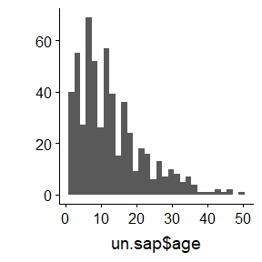

```r
qplot(x = un.sap$age, data = un.sap, geom = "histogram")
```

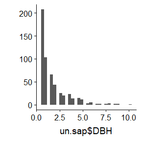

```r
qplot(x = un.sap$DBH, data = un.sap)
```

## UNBURNDED CANOPY: from Beetle

### Data

```r
un.can = read.csv("../data/chapter2_unburnedcanopy_10november2017.csv", header=TRUE, sep = ",", strip.white = TRUE)
head(un.can)
```

|  | plot.mpb | plot | date | plot.id | tree.id | species | live.dead | j.gal | exit.hole | dbh | killed.by | mortality | cones.op.cl | cones | seed.source | canopy.str.field | canopy.str | canopy | cone.ct | fire |
| --- | --- | --- | --- | --- | --- | --- | --- | --- | --- | --- | --- | --- | --- | --- | --- | --- | --- | --- | --- | --- |
| 1 | HU64 | 64 | 6/30/2016 | CEC0630U1 | ne1 | pico | D | Y | Y | 38.0 | MPB | BOM | closed | closed | no | 1.5 | full | yes | 200 | unburned |
| 2 | HU64 | 64 | 6/30/2016 | CEC0630U1 | ne2 | pico | D | Y | Y | 29.5 | MPB | BOM | closed/partial | both | yes | 1.5 | full | yes | 300 | unburned |
| 3 | LU66 | 66 | 7/3/2016 | CEC0703U1 | NE10 | pico | D | O | Y | 10.0 | OPF | BOM | BOTH | both | yes | 1 | full | yes | 10 | unburned |
| 4 | LU66 | 66 | 7/3/2016 | CEC0703U1 | NE2 | pico | L | L | L | 10.0 | LIVE | LIVE | CLOSED | closed | no | 1+NEEDLES | full | yes | 50 | unburned |
| 5 | LU66 | 66 | 7/3/2016 | CEC0703U1 | NE3 | pico | L | L | L | 11.0 | LIVE | LIVE | CLOSED | closed | no | 1+NEEDLES | full | yes | 50 | unburned |
| 6 | LU66 | 66 | 7/3/2016 | CEC0703U1 | NE9 | pico | L | L | L | 12.0 | LIVE | LIVE | CLOSED | closed | no | 1+NEEDLES | full | yes | 75 | unburned |

### Graph data

Let’s look at the Data for anything weird/anomalous. Examine the distributions of the date - are there lots of 1 or 0? is there clumping? are there weird shapes? are there areas of missing data?

#### Explanatory Variables: unburned canopy

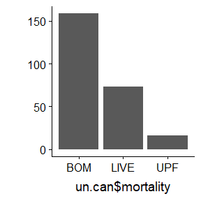

```r
qplot(x = un.can$mortality, data = un.can)
```

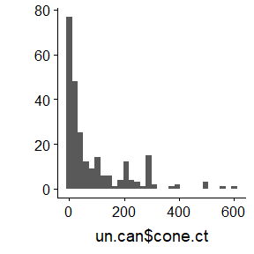

```r
qplot(x = un.can$cone.ct, data = un.can, geom = "histogram")
```

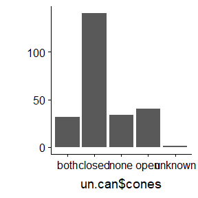

```r
qplot(x = un.can$cones, data = un.can)
```

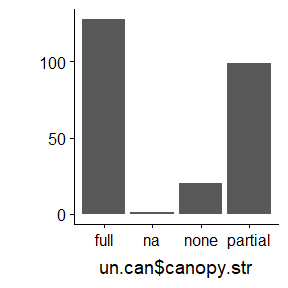

```r
qplot(x = un.can$canopy.str, data = un.can)
```

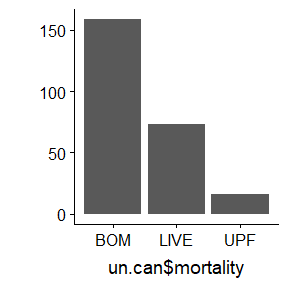

```r
qplot(x = un.can$mortality, data = un.can)
```

```r
with(un.can, table(canopy.str, cones, mortality))
```

```
, , mortality = BOM

          cones
canopy.str both closed none open unknown
   full      11     36    0    7       0
   na         0      1    0    0       0
   none       0      1    9    0       0
   partial   18     48   12   16       0

, , mortality = LIVE

          cones
canopy.str both closed none open unknown
   full       3     54    2   13       1
   na         0      0    0    0       0
   none       0      0    0    0       0
   partial    0      0    0    0       0

, , mortality = UPF

          cones
canopy.str both closed none open unknown
   full       0      0    0    1       0
   na         0      0    0    0       0
   none       0      0   10    0       0
   partial    0      1    1    3       0
```

## UNBURNED: Tree to plot level

```r
head(un.can)
```

|  | plot.mpb | plot | date | plot.id | tree.id | species | live.dead | j.gal | exit.hole | dbh | killed.by | mortality | cones.op.cl | cones | seed.source | canopy.str.field | canopy.str | canopy | cone.ct | fire |
| --- | --- | --- | --- | --- | --- | --- | --- | --- | --- | --- | --- | --- | --- | --- | --- | --- | --- | --- | --- | --- |
| 1 | HU64 | 64 | 6/30/2016 | CEC0630U1 | ne1 | pico | D | Y | Y | 38.0 | MPB | BOM | closed | closed | no | 1.5 | full | yes | 200 | unburned |
| 2 | HU64 | 64 | 6/30/2016 | CEC0630U1 | ne2 | pico | D | Y | Y | 29.5 | MPB | BOM | closed/partial | both | yes | 1.5 | full | yes | 300 | unburned |
| 3 | LU66 | 66 | 7/3/2016 | CEC0703U1 | NE10 | pico | D | O | Y | 10.0 | OPF | BOM | BOTH | both | yes | 1 | full | yes | 10 | unburned |
| 4 | LU66 | 66 | 7/3/2016 | CEC0703U1 | NE2 | pico | L | L | L | 10.0 | LIVE | LIVE | CLOSED | closed | no | 1+NEEDLES | full | yes | 50 | unburned |
| 5 | LU66 | 66 | 7/3/2016 | CEC0703U1 | NE3 | pico | L | L | L | 11.0 | LIVE | LIVE | CLOSED | closed | no | 1+NEEDLES | full | yes | 50 | unburned |
| 6 | LU66 | 66 | 7/3/2016 | CEC0703U1 | NE9 | pico | L | L | L | 12.0 | LIVE | LIVE | CLOSED | closed | no | 1+NEEDLES | full | yes | 75 | unburned |

### Mortality by plot

```r
( un.mort = un.can %>%
  group_by(plot.mpb, plot, mortality) %>%
  summarise(n = n()) %>%
  mutate(stems = sum(n)) %>%
  spread(mortality, n, fill = 0) )
```

| plot.mpb | plot | stems | BOM | LIVE | UPF |
| --- | --- | --- | --- | --- | --- |
| HU64 | 64 | 2 | 2 | 0 | 0 |
| HU65 | 65 | 12 | 11 | 0 | 1 |
| HU70 | 70 | 10 | 10 | 0 | 0 |
| HU71 | 71 | 13 | 9 | 3 | 1 |
| HU78 | 78 | 5 | 4 | 1 | 0 |
| HU81 | 81 | 5 | 4 | 1 | 0 |
| LL72 | 72 | 20 | 8 | 11 | 1 |
| LL75 | 75 | 9 | 5 | 2 | 2 |
| LU66 | 66 | 30 | 15 | 14 | 1 |
| LU74 | 74 | 27 | 11 | 14 | 2 |

[output cut: 10 more lines]

### Canopy Structure by plot

Canopy structure has 3 categories: Full, Partial, None.

```r
( un.canstr = un.can %>%
  group_by(plot.mpb, plot, canopy.str) %>%
  summarise(n = n()) %>%
  mutate(stems = sum(n)) %>%
  spread(canopy.str, n, fill = 0) )
```

| plot.mpb | plot | stems | full | na | none | partial |
| --- | --- | --- | --- | --- | --- | --- |
| HU64 | 64 | 2 | 2 | 0 | 0 | 0 |
| HU65 | 65 | 12 | 0 | 0 | 3 | 9 |
| HU70 | 70 | 10 | 5 | 0 | 1 | 4 |
| HU71 | 71 | 13 | 9 | 0 | 0 | 4 |
| HU78 | 78 | 5 | 2 | 0 | 0 | 3 |
| HU81 | 81 | 5 | 3 | 0 | 0 | 2 |
| LL72 | 72 | 20 | 11 | 0 | 1 | 8 |
| LL75 | 75 | 9 | 3 | 0 | 1 | 5 |
| LU66 | 66 | 30 | 17 | 0 | 2 | 11 |
| LU74 | 74 | 27 | 16 | 0 | 2 | 9 |

[output cut: 10 more lines]

### Canopy by plot

Canopy is yes or no. This has condensed the above with full and partial as yes, and none as no.

```r
( un.canopy = un.can %>%
  group_by(plot.mpb, plot, canopy) %>%
  summarise(n = n()) %>%
  mutate(stems = sum(n)) %>%
  spread(canopy, n, fill = 0) )
```

| plot.mpb | plot | stems | V1 | no | yes |
| --- | --- | --- | --- | --- | --- |
| HU64 | 64 | 2 | 0 | 0 | 2 |
| HU65 | 65 | 12 | 0 | 3 | 9 |
| HU70 | 70 | 10 | 0 | 1 | 9 |
| HU71 | 71 | 13 | 0 | 0 | 13 |
| HU78 | 78 | 5 | 0 | 0 | 5 |
| HU81 | 81 | 5 | 0 | 0 | 5 |
| LL72 | 72 | 20 | 0 | 1 | 19 |
| LL75 | 75 | 9 | 0 | 1 | 8 |
| LU66 | 66 | 30 | 0 | 2 | 28 |
| LU74 | 74 | 27 | 0 | 2 | 25 |

[output cut: 10 more lines]

### Cone type by plot

```r
( un.cone = un.can %>%
  group_by(plot.mpb, plot, cones) %>%
  summarise(n = n()) %>%
  mutate(stems = sum(n)) %>%
  spread(cones, n, fill = 0) )
```

| plot.mpb | plot | stems | both | closed | none | open | unknown |
| --- | --- | --- | --- | --- | --- | --- | --- |
| HU64 | 64 | 2 | 1 | 1 | 0 | 0 | 0 |
| HU65 | 65 | 12 | 6 | 2 | 4 | 0 | 0 |
| HU70 | 70 | 10 | 1 | 6 | 1 | 2 | 0 |
| HU71 | 71 | 13 | 4 | 6 | 0 | 3 | 0 |
| HU78 | 78 | 5 | 0 | 3 | 0 | 2 | 0 |
| HU81 | 81 | 5 | 2 | 3 | 0 | 0 | 0 |
| LL72 | 72 | 20 | 1 | 12 | 3 | 4 | 0 |
| LL75 | 75 | 9 | 0 | 3 | 1 | 5 | 0 |
| LU66 | 66 | 30 | 2 | 19 | 5 | 3 | 1 |
| LU74 | 74 | 27 | 1 | 21 | 3 | 2 | 0 |

[output cut: 10 more lines]

### Seed Source by plot

Seed Source condenses the cone type into a yes no category and classifies a cone as a seed source ‘yes’ if a tree has cones identified as open, both, or partial or identifies a tree as not a seed source ‘no’ if it was classified as closed or none.

```r
( un.seed.source = un.can %>%
  group_by(plot.mpb, plot, seed.source) %>%
  summarise(n = n()) %>%
  mutate(stems = sum(n)) %>%
  spread(seed.source, n, fill = 0) )
```

| plot.mpb | plot | stems | no | yes |
| --- | --- | --- | --- | --- |
| HU64 | 64 | 2 | 1 | 1 |
| HU65 | 65 | 12 | 6 | 6 |
| HU70 | 70 | 10 | 7 | 3 |
| HU71 | 71 | 13 | 6 | 7 |
| HU78 | 78 | 5 | 3 | 2 |
| HU81 | 81 | 5 | 3 | 2 |
| LL72 | 72 | 20 | 15 | 5 |
| LL75 | 75 | 9 | 4 | 5 |
| LU66 | 66 | 30 | 25 | 5 |
| LU74 | 74 | 27 | 24 | 3 |

[output cut: 10 more lines]

### Burn Conditions by Plot

```r
( burn = un.can %>%
  group_by(plot.mpb, plot, fire) %>%
  summarise(n = n()) %>%
  mutate(stems = sum(n)) )
```

| plot.mpb | plot | fire | n | stems |
| --- | --- | --- | --- | --- |
| HU64 | 64 | unburned | 2 | 2 |
| HU65 | 65 | unburned | 12 | 12 |
| HU70 | 70 | unburned | 10 | 10 |
| HU71 | 71 | unburned | 13 | 13 |
| HU78 | 78 | unburned | 5 | 5 |
| HU81 | 81 | unburned | 5 | 5 |
| LL72 | 72 | surface | 20 | 20 |
| LL75 | 75 | surface | 9 | 9 |
| LU66 | 66 | unburned | 30 | 30 |
| LU74 | 74 | unburned | 27 | 27 |

[output cut: 10 more lines]

### Totals cones per plot

```r
( un.totcones = un.can %>%
  na.omit() %>%
  group_by(plot.mpb, plot) %>%
  summarise(cone.ct = sum(cone.ct)) )
```

| plot.mpb | plot | cone.ct |
| --- | --- | --- |
| HU64 | 64 | 500 |
| HU65 | 65 | 475 |
| HU70 | 70 | 2375 |
| HU71 | 71 | 1730 |
| HU78 | 78 | 626 |
| HU81 | 81 | 1205 |
| LL72 | 72 | 1087 |
| LL75 | 75 | 631 |
| LU66 | 66 | 2100 |
| LU74 | 74 | 1980 |

[output cut: 10 more lines]

### UNBURNED: Mortality, Canopy, Seed Source (condensed categories)

```r
u.mortcanopy = merge(un.mort, un.canopy, by = c("plot.mpb", "plot", "stems"))
head(u.mortcanopy)
```

|  | plot.mpb | plot | stems | BOM | LIVE | UPF | V1 | no | yes |
| --- | --- | --- | --- | --- | --- | --- | --- | --- | --- |
| 1 | HU64 | 64 | 2 | 2 | 0 | 0 | 0 | 0 | 2 |
| 2 | HU65 | 65 | 12 | 11 | 0 | 1 | 0 | 3 | 9 |
| 3 | HU70 | 70 | 10 | 10 | 0 | 0 | 0 | 1 | 9 |
| 4 | HU71 | 71 | 13 | 9 | 3 | 1 | 0 | 0 | 13 |
| 5 | HU78 | 78 | 5 | 4 | 1 | 0 | 0 | 0 | 5 |
| 6 | HU81 | 81 | 5 | 4 | 1 | 0 | 0 | 0 | 5 |

```r
u.mortcanopyseed = merge(u.mortcanopy, un.seed.source, by = c("plot.mpb", "plot", "stems"))
head(u.mortcanopyseed)
```

|  | plot.mpb | plot | stems | BOM | LIVE | UPF | V1 | no.x | yes.x | no.y | yes.y |
| --- | --- | --- | --- | --- | --- | --- | --- | --- | --- | --- | --- |
| 1 | HU64 | 64 | 2 | 2 | 0 | 0 | 0 | 0 | 2 | 1 | 1 |
| 2 | HU65 | 65 | 12 | 11 | 0 | 1 | 0 | 3 | 9 | 6 | 6 |
| 3 | HU70 | 70 | 10 | 10 | 0 | 0 | 0 | 1 | 9 | 7 | 3 |
| 4 | HU71 | 71 | 13 | 9 | 3 | 1 | 0 | 0 | 13 | 6 | 7 |
| 5 | HU78 | 78 | 5 | 4 | 1 | 0 | 0 | 0 | 5 | 3 | 2 |
| 6 | HU81 | 81 | 5 | 4 | 1 | 0 | 0 | 0 | 5 | 3 | 2 |

```r
names(u.mortcanopyseed)
```

```
 [1] "plot.mpb" "plot"     "stems"    "BOM"      "LIVE"     "UPF"
 [7] "V1"       "no.x"     "yes.x"    "no.y"     "yes.y"
```

```r
names(u.mortcanopyseed)[8:11] = c("no.canopy", "yes.canopy", "no.seed", "yes.seed")
head(u.mortcanopyseed)
```

|  | plot.mpb | plot | stems | BOM | LIVE | UPF | V1 | no.canopy | yes.canopy | no.seed | yes.seed |
| --- | --- | --- | --- | --- | --- | --- | --- | --- | --- | --- | --- |
| 1 | HU64 | 64 | 2 | 2 | 0 | 0 | 0 | 0 | 2 | 1 | 1 |
| 2 | HU65 | 65 | 12 | 11 | 0 | 1 | 0 | 3 | 9 | 6 | 6 |
| 3 | HU70 | 70 | 10 | 10 | 0 | 0 | 0 | 1 | 9 | 7 | 3 |
| 4 | HU71 | 71 | 13 | 9 | 3 | 1 | 0 | 0 | 13 | 6 | 7 |
| 5 | HU78 | 78 | 5 | 4 | 1 | 0 | 0 | 0 | 5 | 3 | 2 |
| 6 | HU81 | 81 | 5 | 4 | 1 | 0 | 0 | 0 | 5 | 3 | 2 |

```r
u.mortcanopyseedburn = merge(u.mortcanopyseed, burn, by = c("plot.mpb", "plot", "stems"))
head(u.mortcanopyseedburn)
```

|  | plot.mpb | plot | stems | BOM | LIVE | UPF | V1 | no.canopy | yes.canopy | no.seed | yes.seed | fire | n |
| --- | --- | --- | --- | --- | --- | --- | --- | --- | --- | --- | --- | --- | --- |
| 1 | HU64 | 64 | 2 | 2 | 0 | 0 | 0 | 0 | 2 | 1 | 1 | unburned | 2 |
| 2 | HU65 | 65 | 12 | 11 | 0 | 1 | 0 | 3 | 9 | 6 | 6 | unburned | 12 |
| 3 | HU70 | 70 | 10 | 10 | 0 | 0 | 0 | 1 | 9 | 7 | 3 | unburned | 10 |
| 4 | HU71 | 71 | 13 | 9 | 3 | 1 | 0 | 0 | 13 | 6 | 7 | unburned | 13 |
| 5 | HU78 | 78 | 5 | 4 | 1 | 0 | 0 | 0 | 5 | 3 | 2 | unburned | 5 |
| 6 | HU81 | 81 | 5 | 4 | 1 | 0 | 0 | 0 | 5 | 3 | 2 | unburned | 5 |

```r
unburn.plotlevel = merge(u.mortcanopyseedburn, un.totcones, by = c("plot.mpb", "plot"))
head(unburn.plotlevel)
```

|  | plot.mpb | plot | stems | BOM | LIVE | UPF | V1 | no.canopy | yes.canopy | no.seed | yes.seed | fire | n | cone.ct |
| --- | --- | --- | --- | --- | --- | --- | --- | --- | --- | --- | --- | --- | --- | --- |
| 1 | HU64 | 64 | 2 | 2 | 0 | 0 | 0 | 0 | 2 | 1 | 1 | unburned | 2 | 500 |
| 2 | HU65 | 65 | 12 | 11 | 0 | 1 | 0 | 3 | 9 | 6 | 6 | unburned | 12 | 475 |
| 3 | HU70 | 70 | 10 | 10 | 0 | 0 | 0 | 1 | 9 | 7 | 3 | unburned | 10 | 2375 |
| 4 | HU71 | 71 | 13 | 9 | 3 | 1 | 0 | 0 | 13 | 6 | 7 | unburned | 13 | 1730 |
| 5 | HU78 | 78 | 5 | 4 | 1 | 0 | 0 | 0 | 5 | 3 | 2 | unburned | 5 | 626 |
| 6 | HU81 | 81 | 5 | 4 | 1 | 0 | 0 | 0 | 5 | 3 | 2 | unburned | 5 | 1205 |

```r
unburn.plotlevel
```

| plot.mpb | plot | stems | BOM | LIVE | UPF | V1 | no.canopy | yes.canopy | no.seed | yes.seed | fire | n | cone.ct |
| --- | --- | --- | --- | --- | --- | --- | --- | --- | --- | --- | --- | --- | --- |
| HU64 | 64 | 2 | 2 | 0 | 0 | 0 | 0 | 2 | 1 | 1 | unburned | 2 | 500 |
| HU65 | 65 | 12 | 11 | 0 | 1 | 0 | 3 | 9 | 6 | 6 | unburned | 12 | 475 |
| HU70 | 70 | 10 | 10 | 0 | 0 | 0 | 1 | 9 | 7 | 3 | unburned | 10 | 2375 |
| HU71 | 71 | 13 | 9 | 3 | 1 | 0 | 0 | 13 | 6 | 7 | unburned | 13 | 1730 |
| HU78 | 78 | 5 | 4 | 1 | 0 | 0 | 0 | 5 | 3 | 2 | unburned | 5 | 626 |
| HU81 | 81 | 5 | 4 | 1 | 0 | 0 | 0 | 5 | 3 | 2 | unburned | 5 | 1205 |
| LL72 | 72 | 20 | 8 | 11 | 1 | 0 | 1 | 19 | 15 | 5 | surface | 20 | 1087 |
| LL75 | 75 | 9 | 5 | 2 | 2 | 0 | 1 | 8 | 4 | 5 | surface | 9 | 631 |
| LU66 | 66 | 30 | 15 | 14 | 1 | 0 | 2 | 28 | 25 | 5 | unburned | 30 | 2100 |
| LU74 | 74 | 27 | 11 | 14 | 2 | 0 | 2 | 25 | 24 | 3 | unburned | 27 | 1980 |

[output cut: 10 more lines]

```r
write.csv(unburn.plotlevel, file="../output/chapter2_unburn_condensed_10november2017.csv", quote = TRUE, row.names = FALSE, sep = ",")
```

### UNBURNED: Saplings plus condensed category plot

```r
u.plotsapcondensed = merge(unburn.plotlevel, sapling.ct, by = c("plot"))
head(u.plotsapcondensed)
```

|  | plot | plot.mpb | stems | BOM | LIVE | UPF | V1 | no.canopy | yes.canopy | no.seed | yes.seed | fire | n | cone.ct | disturbance | sapling.density |
| --- | --- | --- | --- | --- | --- | --- | --- | --- | --- | --- | --- | --- | --- | --- | --- | --- |
| 1 | 64 | HU64 | 2 | 2 | 0 | 0 | 0 | 0 | 2 | 1 | 1 | unburned | 2 | 500 | beetle.only | 10 |
| 2 | 65 | HU65 | 12 | 11 | 0 | 1 | 0 | 3 | 9 | 6 | 6 | unburned | 12 | 475 | beetle.only | 7 |
| 3 | 66 | LU66 | 30 | 15 | 14 | 1 | 0 | 2 | 28 | 25 | 5 | unburned | 30 | 2100 | beetle.only | 40 |
| 4 | 67 | MU67 | 5 | 5 | 0 | 0 | 0 | 0 | 5 | 3 | 2 | unburned | 5 | 970 | beetle.only | 14 |
| 5 | 68 | MU68 | 26 | 18 | 4 | 4 | 0 | 3 | 23 | 24 | 2 | unburned | 26 | 1618 | beetle.only | 37 |
| 6 | 69 | MU69 | 5 | 5 | 0 | 0 | 0 | 1 | 4 | 3 | 2 | unburned | 5 | 424 | beetle.only | 22 |

```r
write.csv(u.plotsapcondensed, file="../output/chapter2_unburnplotsapcondensed_11november2017.csv", quote = TRUE, row.names = FALSE, sep = ",")
```

```
attempt to set 'sep' ignored
```

# Unburned: Plot Level (condensed categories)

```r
unburn = u.plotsapcondensed
head(unburn)
```

|  | plot | plot.mpb | stems | BOM | LIVE | UPF | V1 | no.canopy | yes.canopy | no.seed | yes.seed | fire | n | cone.ct | disturbance | sapling.density |
| --- | --- | --- | --- | --- | --- | --- | --- | --- | --- | --- | --- | --- | --- | --- | --- | --- |
| 1 | 64 | HU64 | 2 | 2 | 0 | 0 | 0 | 0 | 2 | 1 | 1 | unburned | 2 | 500 | beetle.only | 10 |
| 2 | 65 | HU65 | 12 | 11 | 0 | 1 | 0 | 3 | 9 | 6 | 6 | unburned | 12 | 475 | beetle.only | 7 |
| 3 | 66 | LU66 | 30 | 15 | 14 | 1 | 0 | 2 | 28 | 25 | 5 | unburned | 30 | 2100 | beetle.only | 40 |
| 4 | 67 | MU67 | 5 | 5 | 0 | 0 | 0 | 0 | 5 | 3 | 2 | unburned | 5 | 970 | beetle.only | 14 |
| 5 | 68 | MU68 | 26 | 18 | 4 | 4 | 0 | 3 | 23 | 24 | 2 | unburned | 26 | 1618 | beetle.only | 37 |
| 6 | 69 | MU69 | 5 | 5 | 0 | 0 | 0 | 1 | 4 | 3 | 2 | unburned | 5 | 424 | beetle.only | 22 |

## Calculate Proportions for multi-categories

```r
unburn = mutate(unburn, prop.bom = BOM/stems)
unburn = mutate(unburn, prop.canopy = yes.canopy/stems)
unburn = mutate(unburn, prop.open = yes.seed/stems)
unburn = mutate(unburn, prop.cone.ct = cone.ct/stems)
unburn = mutate(unburn, sapling.log = log(sapling.density))
head(unburn)
```

|  | plot | plot.mpb | stems | BOM | LIVE | UPF | V1 | no.canopy | yes.canopy | no.seed | yes.seed | fire | n | cone.ct | disturbance | sapling.density | prop.bom | prop.canopy | prop.open | prop.cone.ct | sapling.log |
| --- | --- | --- | --- | --- | --- | --- | --- | --- | --- | --- | --- | --- | --- | --- | --- | --- | --- | --- | --- | --- | --- |
| 1 | 64 | HU64 | 2 | 2 | 0 | 0 | 0 | 0 | 2 | 1 | 1 | unburned | 2 | 500 | beetle.only | 10 | 1.0000000 | 1.0000000 | 0.50000000 | 250.00000 | 2.302585 |
| 2 | 65 | HU65 | 12 | 11 | 0 | 1 | 0 | 3 | 9 | 6 | 6 | unburned | 12 | 475 | beetle.only | 7 | 0.9166667 | 0.7500000 | 0.50000000 | 39.58333 | 1.945910 |
| 3 | 66 | LU66 | 30 | 15 | 14 | 1 | 0 | 2 | 28 | 25 | 5 | unburned | 30 | 2100 | beetle.only | 40 | 0.5000000 | 0.9333333 | 0.16666667 | 70.00000 | 3.688879 |
| 4 | 67 | MU67 | 5 | 5 | 0 | 0 | 0 | 0 | 5 | 3 | 2 | unburned | 5 | 970 | beetle.only | 14 | 1.0000000 | 1.0000000 | 0.40000000 | 194.00000 | 2.639057 |
| 5 | 68 | MU68 | 26 | 18 | 4 | 4 | 0 | 3 | 23 | 24 | 2 | unburned | 26 | 1618 | beetle.only | 37 | 0.6923077 | 0.8846154 | 0.07692308 | 62.23077 | 3.610918 |
| 6 | 69 | MU69 | 5 | 5 | 0 | 0 | 0 | 1 | 4 | 3 | 2 | unburned | 5 | 424 | beetle.only | 22 | 1.0000000 | 0.8000000 | 0.40000000 | 84.80000 | 3.091042 |

```r
unburn
```

| plot | plot.mpb | stems | BOM | LIVE | UPF | V1 | no.canopy | yes.canopy | no.seed | yes.seed | fire | n | cone.ct | disturbance | sapling.density | prop.bom | prop.canopy | prop.open | prop.cone.ct | sapling.log |
| --- | --- | --- | --- | --- | --- | --- | --- | --- | --- | --- | --- | --- | --- | --- | --- | --- | --- | --- | --- | --- |
| 64 | HU64 | 2 | 2 | 0 | 0 | 0 | 0 | 2 | 1 | 1 | unburned | 2 | 500 | beetle.only | 10 | 1.0000000 | 1.0000000 | 0.50000000 | 250.00000 | 2.302585 |
| 65 | HU65 | 12 | 11 | 0 | 1 | 0 | 3 | 9 | 6 | 6 | unburned | 12 | 475 | beetle.only | 7 | 0.9166667 | 0.7500000 | 0.50000000 | 39.58333 | 1.945910 |
| 66 | LU66 | 30 | 15 | 14 | 1 | 0 | 2 | 28 | 25 | 5 | unburned | 30 | 2100 | beetle.only | 40 | 0.5000000 | 0.9333333 | 0.16666667 | 70.00000 | 3.688879 |
| 67 | MU67 | 5 | 5 | 0 | 0 | 0 | 0 | 5 | 3 | 2 | unburned | 5 | 970 | beetle.only | 14 | 1.0000000 | 1.0000000 | 0.40000000 | 194.00000 | 2.639057 |
| 68 | MU68 | 26 | 18 | 4 | 4 | 0 | 3 | 23 | 24 | 2 | unburned | 26 | 1618 | beetle.only | 37 | 0.6923077 | 0.8846154 | 0.07692308 | 62.23077 | 3.610918 |
| 69 | MU69 | 5 | 5 | 0 | 0 | 0 | 1 | 4 | 3 | 2 | unburned | 5 | 424 | beetle.only | 22 | 1.0000000 | 0.8000000 | 0.40000000 | 84.80000 | 3.091042 |
| 70 | HU70 | 10 | 10 | 0 | 0 | 0 | 1 | 9 | 7 | 3 | unburned | 10 | 2375 | beetle.only | 21 | 1.0000000 | 0.9000000 | 0.30000000 | 237.50000 | 3.044522 |
| 71 | HU71 | 13 | 9 | 3 | 1 | 0 | 0 | 13 | 6 | 7 | unburned | 13 | 1730 | beetle.only | 3 | 0.6923077 | 1.0000000 | 0.53846154 | 133.07692 | 1.098612 |
| 72 | LL72 | 20 | 8 | 11 | 1 | 0 | 1 | 19 | 15 | 5 | surface | 20 | 1087 | beetle.only | 6 | 0.4000000 | 0.9500000 | 0.25000000 | 54.35000 | 1.791759 |
| 73 | ML73 | 8 | 4 | 4 | 0 | 0 | 0 | 8 | 6 | 2 | surface | 8 | 516 | beetle.only | 42 | 0.5000000 | 1.0000000 | 0.25000000 | 64.50000 | 3.737670 |

[output cut: 10 more lines]

# Graph plot level data

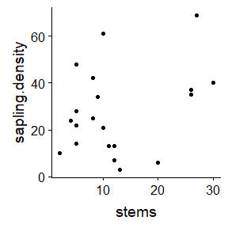

```r
ggplot(data = unburn, aes(x = stems, y = sapling.density)) + geom_point()
```

## Prop. Beetle

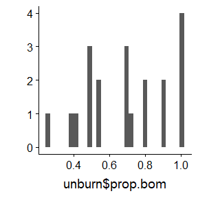

```r
qplot(x = unburn$prop.bom, data = unburn, geom = "histogram")
```

## Proportion stems with canopy structure

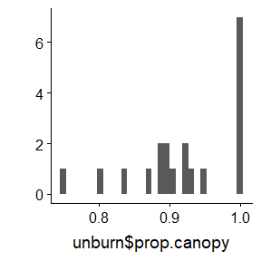

```r
qplot(x = unburn$prop.canopy, data = unburn, geom = "histogram")
```

## Proportion stems with open cones

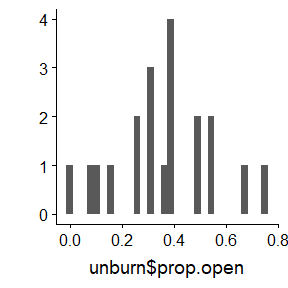

```r
qplot(x = unburn$prop.open, data = unburn, geom = "histogram")
```

## Proportion of cones per stems

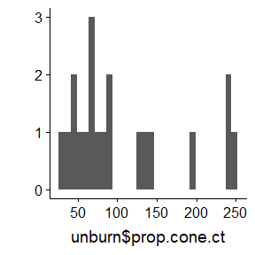

```r
qplot(x = unburn$prop.cone.ct, data = unburn, geom = "histogram")
```

## Correlation plots

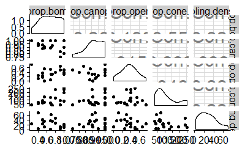

```r
ggpairs( dplyr::select(unburn, prop.bom, prop.canopy, prop.open, prop.cone.ct, sapling.density), upper = list(continuous = wrap("cor", size = 8) ) )
```

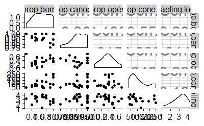

```r
ggpairs( dplyr::select(unburn, prop.bom, prop.canopy, prop.open, prop.cone.ct, sapling.log), upper = list(continuous = wrap("cor", size = 8) ) )
```

# Analysis

Date nofire for beetle only

**Maybe just use linear model???? - NO USEglm.nb because I am working with count data.**

## Model Branch Structure

```r
ucanopy1 = glm.nb(sapling.density ~ prop.canopy + prop.bom, data = unburn)
```

### Residuals with DHARMa

In the plot below we are looking for the points in the QQ plot to fall along the RED linen. In the Residuals vs.predicted plot were are looking for the lines to be relatively horizontal. All looks good.

```
plotSimulatedResiduals is deprecated, switch your code to using the plot function
```

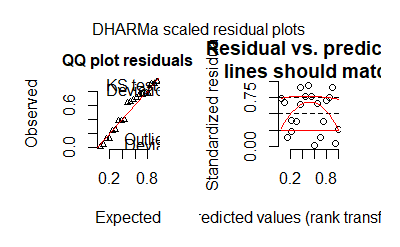

```r
plotSimulatedResiduals(simulationOutput = ucanopy1.res)
```

The qq plot on the left seems ok with no singnificant deviations from the line.

```
testOverdispersion is deprecated, switch your code to using the testDispersion function
```

```
    DHARMa nonparametric dispersion test via sd of residuals fitted
    vs. simulated

data:  simulationOutput
ratioObsSim = 1.0118, p-value = 0.864
alternative hypothesis: two.sided
```

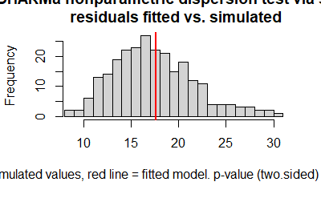

```r
testOverdispersion(ucanopy1.res)
```

### Model Summary No fire

```r
summary(ucanopy1)
```

```
Call:
glm.nb(formula = sapling.density ~ prop.canopy + prop.bom, data = unburn,
    init.theta = 2.594815565, link = log)

Deviance Residuals:
    Min       1Q   Median       3Q      Max
-2.3645  -0.8900   0.1463   0.3698   1.5027

Coefficients:
            Estimate Std. Error z value Pr(>|z|)
(Intercept)   3.6397     2.1424   1.699   0.0893 .
prop.canopy   0.4269     2.1314   0.200   0.8412
prop.bom     -1.0672     0.6683  -1.597   0.1103
---
Signif. codes:  0 *** 0.001 ** 0.01 * 0.05 . 0.1   1

(Dispersion parameter for Negative Binomial(2.5948) family taken to be 1)

    Null deviance: 23.697  on 19  degrees of freedom
Residual deviance: 21.244  on 17  degrees of freedom
AIC: 173.53

Number of Fisher Scoring iterations: 1

              Theta:  2.595
          Std. Err.:  0.880

 2 x log-likelihood:  -165.529
```

#### estimates

```r
( ucanopy1.est = cbind(Estimate = coef(ucanopy1), confint(ucanopy1)) )
```

```
              Estimate     2.5 %    97.5 %
(Intercept)  3.6397012 -1.029139 8.2614691
prop.canopy  0.4269119 -4.259459 5.0962278
prop.bom    -1.0672365 -2.491139 0.3523366
```

```r
( exp(ucanopy1.est))
```

```
              Estimate      2.5 %      97.5 %
(Intercept) 38.0804554 0.35731453 3871.778000
prop.canopy  1.5325177 0.01412994  163.404342
prop.bom     0.3439577 0.08281556    1.422387
```

### Predicted Data Branch Structure

```r
preddat.uncan = data.frame(prop.canopy = unburn$prop.canopy, prop.bom = mean(unburn$prop.bom))
head(preddat.uncan)
```

|  | prop.canopy | prop.bom |
| --- | --- | --- |
| 1 | 1.0000000 | 0.6953568 |
| 2 | 0.7500000 | 0.6953568 |
| 3 | 0.9333333 | 0.6953568 |
| 4 | 1.0000000 | 0.6953568 |
| 5 | 0.8846154 | 0.6953568 |
| 6 | 0.8000000 | 0.6953568 |

```r
predictuncan = predict(ucanopy1, newdata = preddat.uncan, se.fit = TRUE)
ULuncanopy = with(predictuncan, fit + 1.96*se.fit)
LLuncanopy = with(predictuncan, fit - 1.96*se.fit)
unburn = mutate(unburn, predictuncan = exp(predictuncan$fit),
               ULuncanopy = exp(ULuncanopy),
               LLuncanopy = exp(LLuncanopy))
```

### Figure Branch Structure

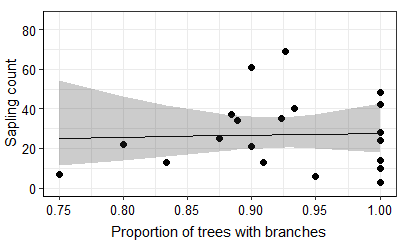

```r
( ucanopygraph = ggplot(data = unburn, aes(x = prop.canopy, y = sapling.density)) +
    geom_point(size = 2) +
    scale_color_manual(values = "black") +
    geom_line(aes(y = predictuncan)) +
    geom_ribbon(aes(ymin = LLuncanopy, ymax = ULuncanopy), alpha = .25) +
    scale_y_continuous(name="Sapling count", limits=c(0, 85), breaks = c(0, 20, 40, 60, 80)) +
    xlab("Proportion of trees with branches")  +
    theme_bw() +
    theme(plot.margin = unit(c(t = 0.3, r = 0.1, b = 0.3, l = 0.1), "cm")) +
    theme(legend.position = "none") +
    theme(axis.title.x = element_text( size = 11, hjust = 0.5, vjust = -0.3),
        axis.title.y = element_text(size = 11, hjust = 0.5, vjust = 1.1),
        axis.text.x = element_text(size = 10, color = "black"),
        axis.text.y = element_text(size = 10, color = "black"),
        panel.background = element_blank(),
        axis.line = element_line(colour = "black")) )
```

## Model open cones + prop.bom

```r
useed1 = glm.nb(sapling.density ~ prop.open + prop.bom, data = unburn)
```

### Residuals with DHARMa

```
plotSimulatedResiduals is deprecated, switch your code to using the plot function
```

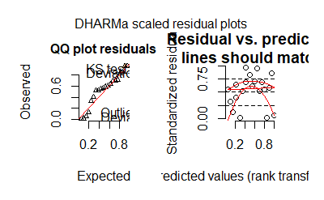

```r
plotSimulatedResiduals(simulationOutput = useed1.res)
```

The qq plot on the left seems ok with no singnificant deviations from the line.

```
testOverdispersion is deprecated, switch your code to using the testDispersion function
```

```
    DHARMa nonparametric dispersion test via sd of residuals fitted
    vs. simulated

data:  simulationOutput
ratioObsSim = 0.9993, p-value = 0.864
alternative hypothesis: two.sided
```

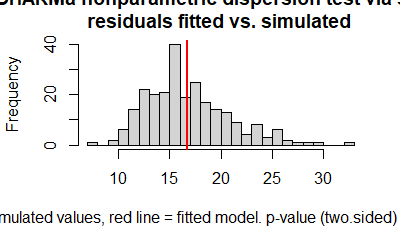

```r
testOverdispersion(useed1.res)
```

### Model Summary No fire

```r
summary(useed1)
```

```
Call:
glm.nb(formula = sapling.density ~ prop.open + prop.bom, data = unburn,
    init.theta = 2.956916086, link = log)

Deviance Residuals:
     Min        1Q    Median        3Q       Max
-2.29096  -0.53933  -0.03585   0.36548   1.44866

Coefficients:
            Estimate Std. Error z value Pr(>|z|)
(Intercept)   4.3534     0.4787   9.094   <2e-16 ***
prop.open    -1.3208     0.7451  -1.773   0.0763 .
prop.bom     -0.8738     0.6246  -1.399   0.1619
---
Signif. codes:  0 *** 0.001 ** 0.01 * 0.05 . 0.1   1

(Dispersion parameter for Negative Binomial(2.9569) family taken to be 1)

    Null deviance: 26.545  on 19  degrees of freedom
Residual deviance: 21.143  on 17  degrees of freedom
AIC: 171.03

Number of Fisher Scoring iterations: 1

              Theta:  2.96
          Std. Err.:  1.03

 2 x log-likelihood:  -163.033
```

#### estimates

```r
( useed1.est = cbind(Estimate = coef(useed1), confint(useed1)) )
```

```
             Estimate     2.5 %    97.5 %
(Intercept)  4.353423  3.370566 5.4042397
prop.open   -1.320780 -2.854448 0.2670202
prop.bom    -0.873786 -2.167231 0.3825549
```

```r
( exp(useed1.est))
```

```
              Estimate       2.5 %     97.5 %
(Intercept) 77.7441268 29.09499762 222.347109
prop.open    0.2669270  0.05758762   1.306067
prop.bom     0.4173684  0.11449425   1.466025
```

### Predicted Data Open Cones

```r
preddat.useed = data.frame(prop.open = unburn$prop.open, prop.bom = mean(unburn$prop.bom))
head(preddat.useed)
```

|  | prop.open | prop.bom |
| --- | --- | --- |
| 1 | 0.50000000 | 0.6953568 |
| 2 | 0.50000000 | 0.6953568 |
| 3 | 0.16666667 | 0.6953568 |
| 4 | 0.40000000 | 0.6953568 |
| 5 | 0.07692308 | 0.6953568 |
| 6 | 0.40000000 | 0.6953568 |

```r
predictuseed = predict(useed1, newdata = preddat.useed, se.fit = TRUE)
ULuseed = with(predictuseed, fit + 1.96*se.fit)
LLuseed = with(predictuseed, fit - 1.96*se.fit)
unburn = mutate(unburn, predictuseed = exp(predictuseed$fit),
               ULuseed = exp(ULuseed),
               LLuseed = exp(LLuseed))
```

### Figure Open Cones

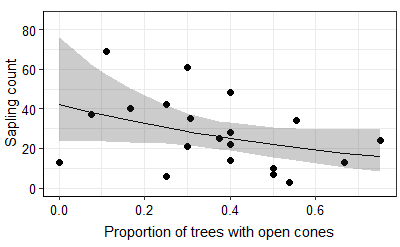

```r
( useedgraph = ggplot(data = unburn, aes(x = prop.open, y = sapling.density)) +
    geom_point(size = 2) +
    scale_color_manual(values = "black") +
    geom_line(aes(y = predictuseed)) +
    geom_ribbon(aes(ymin = LLuseed, ymax = ULuseed), alpha = .25) +
    xlab("Proportion of trees with open cones")  +
    scale_y_continuous(name="Sapling count", limits=c(0, 85), breaks = c(0, 20, 40, 60, 80)) +
    theme_bw() +
    theme(plot.margin = unit(c(t = 0.3, r = 0.1, b = 0.3, l = 0.1), "cm")) +
    theme(legend.position = "none") +
    theme(axis.title.x = element_text(size = 11, hjust = 0.5, vjust = -0.3),
        axis.title.y = element_text(size = 11, hjust = 0.5, vjust = 1.1),
        axis.text.x = element_text(size = 10, color = "black"),
        axis.text.y = element_text(size = 10, color = "black"),
        panel.background = element_blank(),
        axis.line = element_line(colour = "black")) )
```

## Model Cones

```r
ucones1 = glm.nb(sapling.density ~ prop.cone.ct + prop.bom, data = unburn)
```

### Residuals with DHARMa

In the plot below we are looking for the points in the QQ plot to fall along the RED linen. In the Residuals vs.predicted plot were are looking for the lines to be relatively horizontal. All looks good.

```
plotSimulatedResiduals is deprecated, switch your code to using the plot function
```

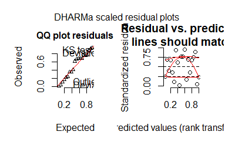

```r
plotSimulatedResiduals(simulationOutput = ucones1.res)
```

The qq plot on the left seems ok with no singnificant deviations from the line.

```
testOverdispersion is deprecated, switch your code to using the testDispersion function
```

```
    DHARMa nonparametric dispersion test via sd of residuals fitted
    vs. simulated

data:  simulationOutput
ratioObsSim = 0.99653, p-value = 0.888
alternative hypothesis: two.sided
```

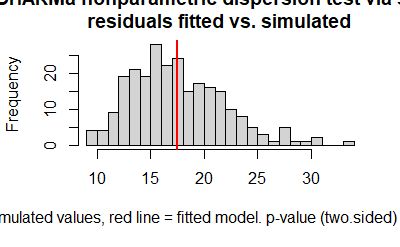

```r
testOverdispersion(ucones1.res)
```

### Model Summary No fire

```r
summary(ucones1)
```

```
Call:
glm.nb(formula = sapling.density ~ prop.cone.ct + prop.bom, data = unburn,
    init.theta = 2.597306094, link = log)

Deviance Residuals:
    Min       1Q   Median       3Q      Max
-2.3245  -0.8308   0.1323   0.3839   1.4207

Coefficients:
               Estimate Std. Error z value Pr(>|z|)
(Intercept)   4.0414765  0.4689852   8.617   <2e-16 ***
prop.cone.ct -0.0004876  0.0025456  -0.192    0.848
prop.bom     -1.0029070  0.7717988  -1.299    0.194
---
Signif. codes:  0 *** 0.001 ** 0.01 * 0.05 . 0.1   1

(Dispersion parameter for Negative Binomial(2.5973) family taken to be 1)

    Null deviance: 23.717  on 19  degrees of freedom
Residual deviance: 21.254  on 17  degrees of freedom
AIC: 173.52

Number of Fisher Scoring iterations: 1

              Theta:  2.597
          Std. Err.:  0.881

 2 x log-likelihood:  -165.520
```

#### estimates

```r
( ucones1.est = cbind(Estimate = coef(ucones1), confint(ucones1)) )
```

```
                  Estimate       2.5 %      97.5 %
(Intercept)   4.0414765032  3.07568653 5.084484120
prop.cone.ct -0.0004875889 -0.00519045 0.004324168
prop.bom     -1.0029069879 -2.65058519 0.653141663
```

```r
( uncones1.exp = exp(ucones1.est) )
```

```
               Estimate       2.5 %     97.5 %
(Intercept)  56.9103091 21.66475033 161.496605
prop.cone.ct  0.9995125  0.99482300   1.004334
prop.bom      0.3668116  0.07060988   1.921568
```

## Predicted Data Cones

```r
preddat.ucones = data.frame(prop.cone.ct = unburn$prop.cone.ct, prop.bom = mean(unburn$prop.bom))
head(preddat.ucones)
```

|  | prop.cone.ct | prop.bom |
| --- | --- | --- |
| 1 | 250.00000 | 0.6953568 |
| 2 | 39.58333 | 0.6953568 |
| 3 | 70.00000 | 0.6953568 |
| 4 | 194.00000 | 0.6953568 |
| 5 | 62.23077 | 0.6953568 |
| 6 | 84.80000 | 0.6953568 |

```r
predictucones = predict(ucones1, newdata = preddat.ucones, se.fit = TRUE)
ULucones = with(predictucones, fit + 1.96*se.fit)
LLucones = with(predictucones, fit - 1.96*se.fit)
unburn = mutate(unburn, predictucones = exp(predictucones$fit),
               ULucones = exp(ULucones),
               LLucones = exp(LLucones))
```

### Figure

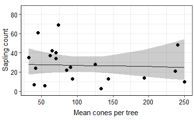

```r
( uconesgraph = ggplot(data = unburn, aes(x = prop.cone.ct, y = sapling.density)) +
    geom_point(size = 2) +
    scale_color_manual(values = "black") +
    geom_line(aes(y = predictucones)) +
    geom_ribbon(aes(ymin = LLucones, ymax = ULucones), alpha = .25) +
    xlab("Mean cones per tree")  +
    scale_y_continuous(name="Sapling count", limits=c(0, 85), breaks = c(0, 20, 40, 60, 80)) +
    theme_bw() +
    theme(plot.margin = unit(c(t = 0.3, r = 0.1, b = 0.3, l = 0.1), "cm")) +
    theme(legend.position = "none") +
    theme(axis.title.x = element_text(size = 11, hjust = 0.5, vjust = -0.3),
        axis.title.y = element_text(size = 11, hjust = 0.5, vjust = 1.1),
        axis.text.x = element_text(size = 10, color = "black"),
        axis.text.y = element_text(size = 10, color = "black"),
        panel.background = element_blank(),
        axis.line = element_line(colour = "black")) )
```

## Model beetle outbreak

```r
beetle1 = glm.nb(sapling.density ~ prop.bom, data = unburn)
```

### Residuals with DHARMa

In the plot below we are looking for the points in the QQ plot to fall along the RED linen. In the Residuals vs.predicted plot were are looking for the lines to be relatively horizontal. All looks good.

```
plotSimulatedResiduals is deprecated, switch your code to using the plot function
```

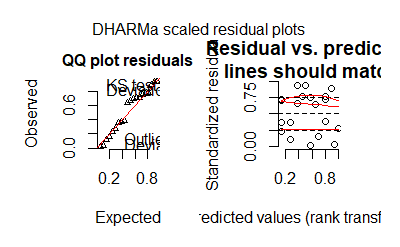

```r
plotSimulatedResiduals(simulationOutput = beetle1.res)
```

The qq plot on the left seems ok with no singnificant deviations from the line.

```
testOverdispersion is deprecated, switch your code to using the testDispersion function
```

```
    DHARMa nonparametric dispersion test via sd of residuals fitted
    vs. simulated

data:  simulationOutput
ratioObsSim = 1.0052, p-value = 0.896
alternative hypothesis: two.sided
```

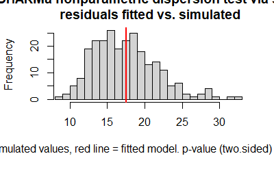

```r
testOverdispersion(beetle1.res)
```

### Summary

```r
summary(beetle1)
```

```
Call:
glm.nb(formula = sapling.density ~ prop.bom, data = unburn, init.theta = 2.591014051,
    link = log)

Deviance Residuals:
    Min       1Q   Median       3Q      Max
-2.3342  -0.8573   0.1295   0.4033   1.4805

Coefficients:
            Estimate Std. Error z value Pr(>|z|)
(Intercept)   4.0534     0.4689   8.645   <2e-16 ***
prop.bom     -1.0946     0.6455  -1.696   0.0899 .
---
Signif. codes:  0 *** 0.001 ** 0.01 * 0.05 . 0.1   1

(Dispersion parameter for Negative Binomial(2.591) family taken to be 1)

    Null deviance: 23.667  on 19  degrees of freedom
Residual deviance: 21.249  on 18  degrees of freedom
AIC: 171.56

Number of Fisher Scoring iterations: 1

              Theta:  2.591
          Std. Err.:  0.878

 2 x log-likelihood:  -165.561
```

#### estimates

```r
( beetle1.est = cbind(Estimate = coef(beetle1), confint(beetle1)) )
```

```
             Estimate     2.5 %    97.5 %
(Intercept)  4.053422  3.089564 5.0912076
prop.bom    -1.094633 -2.490121 0.2853094
```

```r
( beetle1.exp = exp(beetle1.est) )
```

```
              Estimate       2.5 %     97.5 %
(Intercept) 57.5942161 21.96749270 162.586087
prop.bom     0.3346623  0.08289997   1.330174
```

## Predicted Data

```r
preddat.beetle = data.frame(prop.bom = unburn$prop.bom)
head(preddat.beetle)
```

|  | prop.bom |
| --- | --- |
| 1 | 1.0000000 |
| 2 | 0.9166667 |
| 3 | 0.5000000 |
| 4 | 1.0000000 |
| 5 | 0.6923077 |
| 6 | 1.0000000 |

```r
predictbeetle = predict(beetle1, newdata = preddat.beetle, se.fit = TRUE)
ULbeetle = with(predictbeetle, fit + 1.96*se.fit)
LLbeetle = with(predictbeetle, fit - 1.96*se.fit)
unburn = mutate(unburn, predictbeetle = exp(predictbeetle$fit),
               ULbeetle = exp(ULbeetle),
               LLbeetle = exp(LLbeetle))
```

### Figure

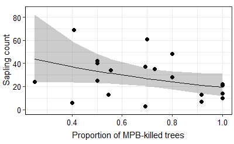

```r
( beetlegraph = ggplot(data = unburn, aes(x = prop.bom, y = sapling.density)) +
    geom_point(size = 2) +
    scale_color_manual(values = "black") +
    geom_line(aes(y = predictbeetle)) +
    geom_ribbon(aes(ymin = LLbeetle, ymax = ULbeetle), alpha = .25) +
    xlab("Proportion of MPB-killed trees")  +
    scale_y_continuous(name="Sapling count", limits=c(0, 85), breaks = c(0, 20, 40, 60, 80)) +
    theme_bw() +
    theme(plot.margin = unit(c(t = 0.3, r = 0.1, b = 0.3, l = 0.1), "cm")) +
    theme(legend.position = "none") +
    theme(axis.title.x = element_text(size = 11, hjust = 0.5, vjust = -0.3),
        axis.title.y = element_text(size = 11, hjust = 0.5, vjust = 1.1),
        axis.text.x = element_text(size = 10, color = "black"),
        axis.text.y = element_text(size = 10, color = "black"),
        panel.background = element_blank(),
        axis.line = element_line(colour = "black")) )
```

## COMBINE UNBURNED PLOTS

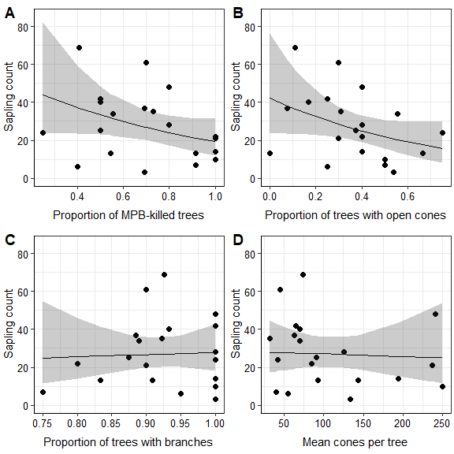

```r
( plotunburned1.1 = cowplot::plot_grid(beetlegraph, useedgraph, ucanopygraph, uconesgraph, labels = c("A","B", "C", "D"), align = "hv", ncol= 2) )
```

# Graph + Photo

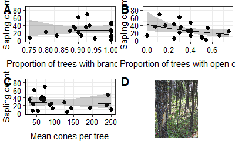

```r
library(magick)
photo4 = ggdraw() + draw_image("../img/unburned3.png", scale = 0.8)
( grid4 = cowplot::plot_grid(ucanopygraph, useedgraph, uconesgraph, photo4,
                               labels = c("A","B", "C", "D"),
                               ncol= 2) )
```

# AIC to assess explanatory varaibles

## Null Model

```r
unull1 = glm.nb(sapling.density ~ prop.bom, data = unburn)
```

### Residuals with DHARMa

In the plot below we are looking for the points in the QQ plot to fall along the RED linen. In the Residuals vs.predicted plot were are looking for the lines to be relatively horizontal. All looks good.

```
plotSimulatedResiduals is deprecated, switch your code to using the plot function
```

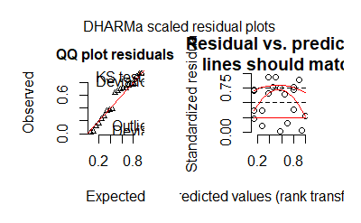

```r
plotSimulatedResiduals(simulationOutput = unull1.res)
```

The qq plot on the left seems ok with no singnificant deviations from the line.

```
testOverdispersion is deprecated, switch your code to using the testDispersion function
```

```
    DHARMa nonparametric dispersion test via sd of residuals fitted
    vs. simulated

data:  simulationOutput
ratioObsSim = 1.0052, p-value = 0.896
alternative hypothesis: two.sided
```

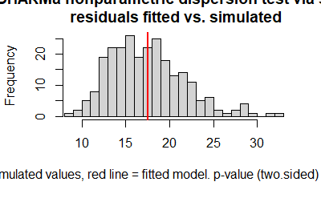

```r
testOverdispersion(unull1.res)
```

### Model Summary No fire

```r
summary(unull1)
```

```
Call:
glm.nb(formula = sapling.density ~ prop.bom, data = unburn, init.theta = 2.591014051,
    link = log)

Deviance Residuals:
    Min       1Q   Median       3Q      Max
-2.3342  -0.8573   0.1295   0.4033   1.4805

Coefficients:
            Estimate Std. Error z value Pr(>|z|)
(Intercept)   4.0534     0.4689   8.645   <2e-16 ***
prop.bom     -1.0946     0.6455  -1.696   0.0899 .
---
Signif. codes:  0 *** 0.001 ** 0.01 * 0.05 . 0.1   1

(Dispersion parameter for Negative Binomial(2.591) family taken to be 1)

    Null deviance: 23.667  on 19  degrees of freedom
Residual deviance: 21.249  on 18  degrees of freedom
AIC: 171.56

Number of Fisher Scoring iterations: 1

              Theta:  2.591
          Std. Err.:  0.878

 2 x log-likelihood:  -165.561
```

#### estimates

```r
( unull1.est = cbind(Estimate = coef(unull1), confint(unull1)) )
```

```
             Estimate     2.5 %    97.5 %
(Intercept)  4.053422  3.089564 5.0912076
prop.bom    -1.094633 -2.490121 0.2853094
```

```r
( exp(unull1.est))
```

```
              Estimate       2.5 %     97.5 %
(Intercept) 57.5942161 21.96749270 162.586087
prop.bom     0.3346623  0.08289997   1.330174
```

```r
AIC(unull1, ucones1, useed1, ucanopy1)
```

|  | df | AIC |
| --- | --- | --- |
| unull1 | 3 | 171.5609 |
| ucones1 | 4 | 173.5203 |
| useed1 | 4 | 171.0327 |
| ucanopy1 | 4 | 173.5286 |

**THE END**